# doc2concrete

Tae-Ung

3/18/2021

## Load the forum data

```r
result <- fromJSON(file = "~/workspace/greenschool/forum/master_dict_after_a07.json")
data_wide <- result %>%
        unlist() %>%
        enframe() %>%
        separate(name, into = c('mid', 'name'), sep = "([.])") %>%
        spread(name, value)
rm(result)

# Data with any unitid
data_wide_w_unitid <- data_wide %>%
        filter(univid != '999999')

# Data with contents containing any keywords (stars, tracking, rating, reporting)
data_wide_stars <- data_wide %>%
        filter(str_detect(cleaned_contents, 'stars|tracking|rating|reporting'))
```

## Define Functions

```r
d2c_process <- function(data, domain, numCores, wordlist) {
        d2c_result <- doc2concrete(
                data$cleaned_contents,
                domain = c(domain),  #"open", "advice", "plans"
                wordlist = wordlist,
                stop.words = TRUE,
                number.words = FALSE,
                shrink = FALSE,
                fill = FALSE,
                uk_english = FALSE,
                num.mc.cores = numCores)
        data_wide_a <- data %>%
                add_column(d2c_score = d2c_result)
        data_wide_a
}

d2c_plotting_by_years <- function(data, start_year, ftitle) {
        data %>%
                filter(year >= start_year) %>%
                group_by(year) %>%
                summarise(
                        n=n(),
                        mean=mean(d2c_score, na.rm = TRUE),
                        sd=sd(d2c_score, na.rm = TRUE)
                ) %>%
                mutate(se = sd/sqrt(n))  %>%
                mutate(ic = se*qt((1-0.05)/2 + .5, n-1)) %>%
                ggplot() +
                geom_bar(aes(x=year, y=mean), stat="identity", fill="gray70") +
                geom_errorbar(aes(x=year, ymin=mean-ic, ymax=mean+ic), width=0.3,
                              colour="black", alpha=0.9, size=0.3) +
                ggtitle(ftitle) +
                theme(axis.text.x = element_text(angle = 60, hjust = 1, vjust = 1))
}
```

```r
numCores <- detectCores()

## Overall data
data_wide_d2c <- d2c_process(data_wide, 'open', numCores, doc2concrete::mturk_list)
```

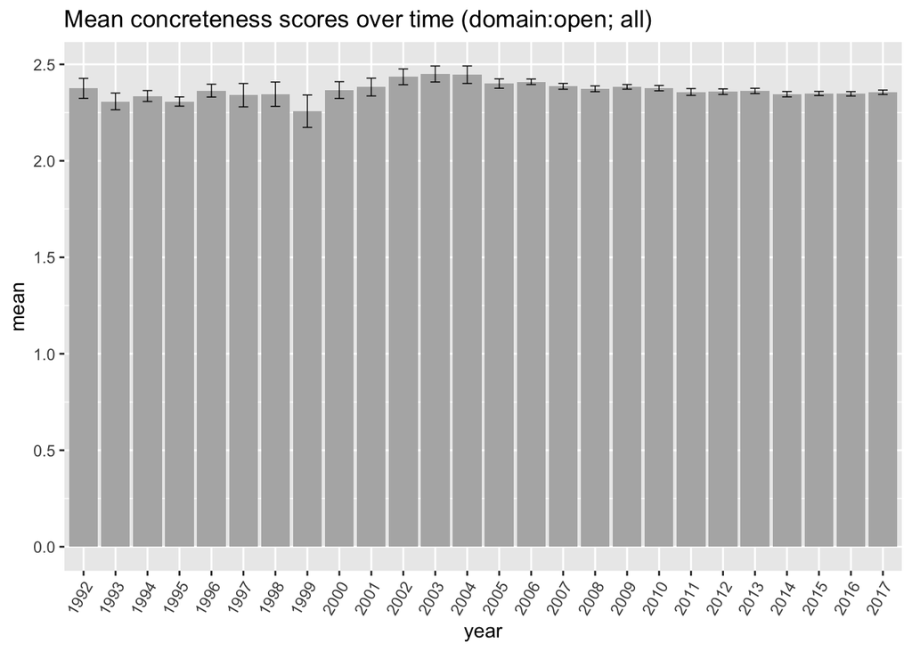

```r
d2c_plotting_by_years(data_wide_d2c, start_year = 1990, ftitle = "Mean concreteness scores over time (domain:open; all)")
```

```r
## With unitid identifiers
data_wide_d2c_unitid <- d2c_process(data_wide_w_unitid, 'open', numCores, doc2concrete::mturk_list)
```

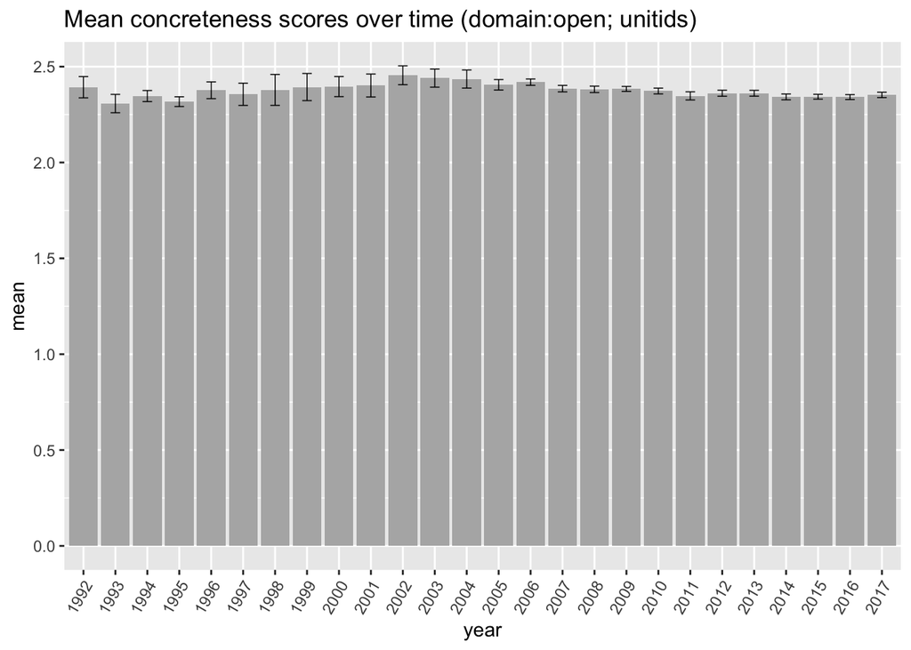

```r
d2c_plotting_by_years(data_wide_d2c_unitid, start_year = 1990, ftitle = "Mean concreteness scores over time (domain:open; unitids)")
```

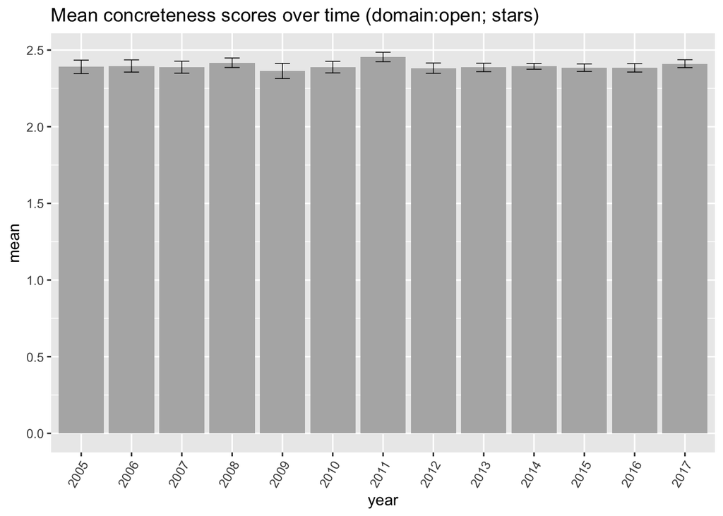

```r
## With STARS-related keywords
data_wide_d2c_stars <- d2c_process(data_wide_stars, 'open', numCores, doc2concrete::mturk_list)
d2c_plotting_by_years(data_wide_d2c_stars, start_year = 2005, ftitle = "Mean concreteness scores over time (domain:open; stars)")
```

## Underlying Concreteness Dictionary

“Although it is not ideal, researchers may have to rely on a domain-general model if they are in an unfamiliar domain, or conducting exploratory work. In this case, our results suggest that the mTurk dictionary provides the most robust measure of concreteness across the domains we tested here (Brysbeart et al., 2014). We also found substantial variation in concreteness within and across domains, however we provide this open-domain model as a scaleable starting point for researchers interested in other domains. **However, we highly recommend that researchers conduct deeper work to better understand their own domain-specific model of concreteness.**” (source: https://cran.r-project.org/web/packages/doc2concrete/vignettes/doc2concrete.html)

“There are many domains where such pre-training is not yet possible. Accordingly, we provide support for two off-the-shelf concreteness”dictionaries" - i.e. document-level aggregations of word-level scores. We found that that have modest (but consistent) accuracy across domains and contexts. However, we still encourage researchers to train a model of concreteness in their own domain, if possible." (source: -doc2concrete- R documentation)

```r
domain_general_dictionary <- as.data.frame(doc2concrete::mturk_list)

# randomly select numbers
random_elements <- sample.int(length(domain_general_dictionary$Word), 50)

domain_general_dictionary[random_elements,] %>%
  arrange(desc(Conc.M)) %>%
  kbl(caption = "50 randomly selected words") %>%
  kable_classic(full_width = FALSE, position = "left")
```

50 randomly selected words

| Word | Conc.M |
| --- | --- |
| feces | 4.96 |
| tennis racket | 4.96 |
| jigsaw puzzle | 4.93 |
| air base | 4.83 |
| cheese | 4.70 |
| cellophane | 4.54 |
| teacher | 4.52 |
| fat | 4.52 |
| specimen | 4.45 |
| homeroom | 4.30 |
| chop off | 4.00 |
| monofilament | 3.83 |
| sucker | 3.79 |
| jotting | 3.39 |
| wipeout | 3.37 |
| clockwork | 3.36 |
| blondish | 3.30 |
| bit | 3.27 |
| accounting | 3.27 |
| fathered | 3.21 |
| veer | 3.19 |
| forgiver | 3.17 |
| stalked | 3.00 |
| search | 3.00 |
| tempo | 2.81 |
| towards | 2.79 |
| retelling | 2.70 |
| recovery | 2.68 |
| scriptural | 2.65 |
| noncertified | 2.63 |
| speedily | 2.48 |
| lawful | 2.46 |
| referral | 2.43 |
| dogged | 2.26 |
| sass | 2.26 |
| opposition | 2.25 |
| reactivity | 2.24 |
| lionhearted | 2.19 |
| anarchy | 2.12 |
| misgauge | 2.04 |
| inhospitableness | 2.00 |
| affectedly | 1.92 |
| depreciate | 1.89 |
| ideological | 1.85 |
| eventful | 1.79 |
| ironical | 1.68 |
| unmissed | 1.60 |
| uncritically | 1.59 |
| influentially | 1.55 |
| liberalness | 1.32 |

```r
domain_general_dictionary %>%
  filter(Word %in% c('compost', 'sustainable', 'school', 'green', 'forum', 'manager', 'sustain', 'climate',
                     'challenge', 'office', 'certification', 'recycling', 'reporting', 'student', 'initiative',
                     'literacy', 'consultant', 'campus', 'ecology', 'global', 'warming', 'engagement', 'engage',
                     'diversity', 'biodiversity', 'facility', 'collaboration', 'efficiency', 'energy', 'waste',
                     'water', 'committee', 'equity', 'diversity', 'global warming', 'fossil fuel', 'fuel',
                     'fossil', 'investment', 'divest', 'climate change', 'practice', 'policy')) %>%
  arrange(desc(Conc.M)) %>%
  kbl(caption = "Sustainability-related words") %>%
  kable_classic(full_width = FALSE, position = "left")
```

Sustainability-related words

| Word | Conc.M |
| --- | --- |
| water | 5.00 |
| office | 4.93 |
| student | 4.92 |
| fossil | 4.90 |
| school | 4.79 |
| campus | 4.64 |
| compost | 4.46 |
| fuel | 4.30 |
| committee | 4.14 |
| manager | 4.14 |
| green | 4.07 |
| forum | 4.00 |
| consultant | 3.97 |
| certification | 3.72 |
| investment | 3.59 |
| facility | 3.58 |
| climate | 3.50 |
| warming | 3.34 |
| recycling | 3.25 |
| waste | 3.24 |
| energy | 3.11 |
| global warming | 3.10 |
| climate change | 2.96 |
| global | 2.93 |
| policy | 2.76 |
| engagement | 2.75 |
| ecology | 2.64 |
| collaboration | 2.59 |
| practice | 2.52 |
| diversity | 2.28 |
| equity | 2.22 |
| sustainable | 2.21 |
| biodiversity | 2.19 |
| sustain | 2.17 |
| efficiency | 2.15 |
| challenge | 2.11 |
| engage | 2.07 |
| literacy | 2.04 |
| initiative | 2.03 |